# Noshow prediction in hair saloon

Anna Golovchenko

Data Description

The main task is to predict the bookings most likely to end up with a no-show. Here we posess the information about the client’s previous bookings, cancelations and no-shows as well as service and cost information.

**book_tod** The booking time of day.

**book_dow** The booking day-of-week.

**book_category** The booked service category (COLOR or STYLE)

**book_staff** The staff member to provide the service.

**last_day_services** The number of services provided to the client on their last visit before the current booking or today whichever is greater.

**last_receipt_tot** The amount paid by the client on their last visit before the current booking or today whichever is greater.

**last_noshow** Did the client no-show on their last booking before the current booking or today whichever is greater? (0 - no, 1 - yes)

**last_prod_flag** Did the client buy a retail product on their last booking before the current booking or today whichever is greater? (0 - no, 1 - yes)

**last_cumrev** The client’s cumulative service revenue as of their last booking before the current booking or today whichever is greater.

**last_cumbook** The client’s cumulative number of bookings as of their last booking before the current booking or today whichever is greater.

**last_cumstyle** The client’s cumulative number of STYLE bookings as of their last booking before the current booking or today whichever is greater.

**last_cumcolor** The client’s cumulative number of COLOR bookings as of their last booking before the current booking or today whichever is greater.

**last_cumprod** The client’s cumulative number of bookings with retail product purchases as of their last booking before the current booking or today whichever is greater.

**last_cumcancel** The client’s cumulative number of appointment cancellations as of their last booking before the current booking or today whichever is greater.

**last_cumnoshow** The client’s cumulative number of no-shows as of their last booking before the current booking or today whichever is greater.

**noshow** Did the client no-show or execute an out-of-policy cancellation for this booking? (0 - no, 1 - yes) recencyThe number of days since the client’s last booking before the current booking or today whichever is greater.

```r
library(readr)
library(dplyr)

full_df <- read_csv("~/Documents/repositories/no_show/data/hair_salon_no_show_wrangled_df.csv")

full_df$noshow <- as.factor(full_df$noshow)
full_df$book_category <- as.factor(full_df$book_category)
full_df$book_staff <- as.factor(full_df$book_staff)
full_df$last_staff <- as.factor(full_df$last_staff)
full_df$last_category <- as.factor(full_df$last_category)
full_df$book_dow <- as.factor(full_df$book_dow)
full_df$book_tod <- as.factor(full_df$book_tod)

full_df = dplyr::select(full_df, - last_dow, -last_tod, -X1)

full_df$book_tod <- ifelse(is.na(full_df$book_tod), "unknown", as.character(full_df$book_tod))
```

### Let’s add some features

```r
# Does the staff match from the previous visist?
full_df$staff_match = ifelse(full_df$book_staff == full_df$last_staff, 1, 0)
full_df$staff_match = ifelse(is.na(full_df$staff_match), 0, full_df$staff_match)
# Does the category match from the previous visit?
full_df$category_match = ifelse(full_df$book_category == full_df$last_category, 1, 0)
full_df$category_match = ifelse(is.na(full_df$category_match), 0, full_df$category_match)

full_df <- select(full_df, - last_category, -last_staff)
```

We can plot some features

## Who gets more noshows among the staff?

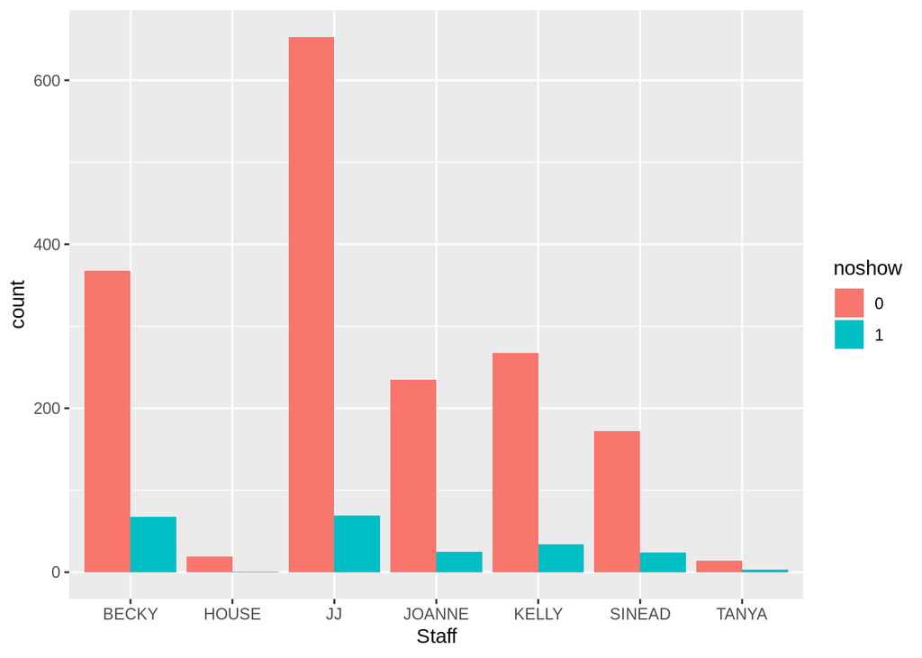

```r
library(ggplot2)

ggplot(full_df) +
  geom_bar(aes(x = book_staff, fill = noshow), position = "dodge") + xlab("Staff")
```

**It seems that Becky has a higher proportion of noshows.**

## May the total price of the previous receipt (if any) influence the tendency to skip an appoitment?

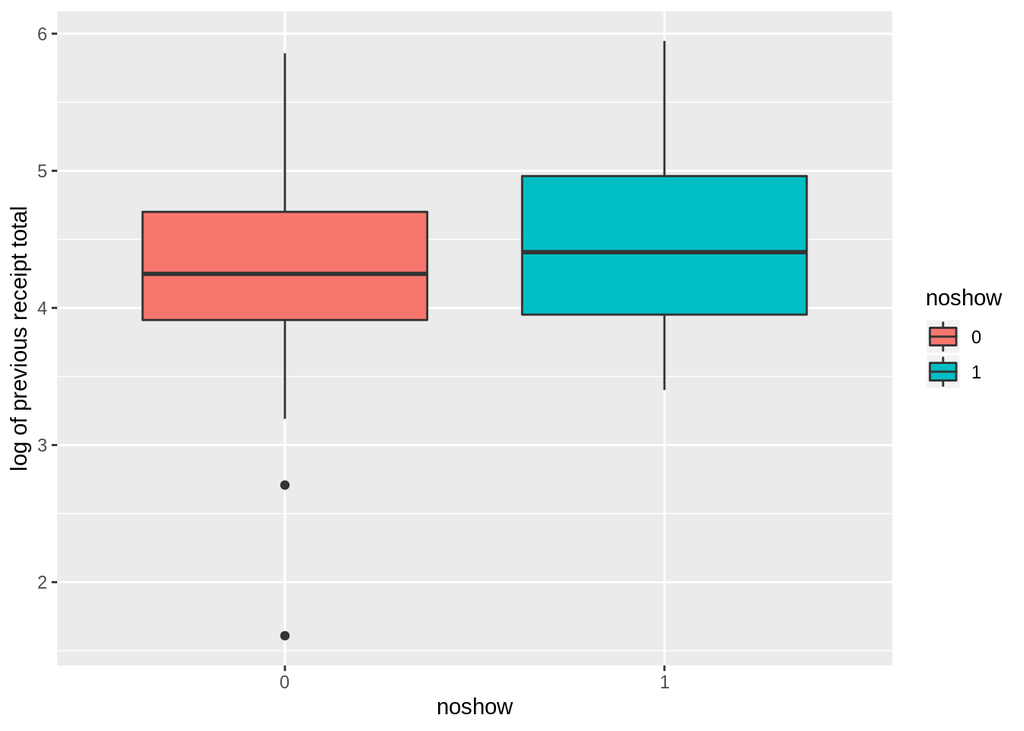

```r
ggplot(full_df) +
  geom_boxplot(aes(x = noshow, y = log(last_receipt_tot), fill = noshow)) +
  ylab("log of previous receipt total")
```

```r
# zeros removed from the plot
```

**According to the plot, there’s no significant difference.**

## What weekdays and time of the day do account for most of the noshows?

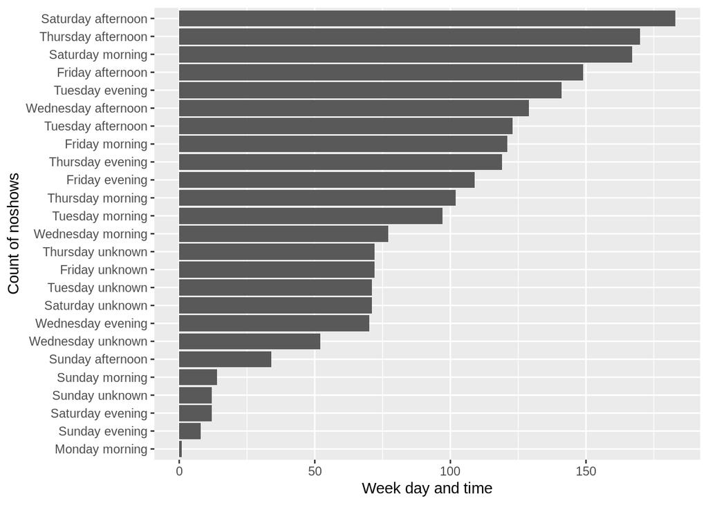

```r
days_times = full_df %>% group_by(book_dow, book_tod) %>% summarise(count_noshows = sum(as.numeric(noshow))) %>% arrange(desc(count_noshows))

days_times$day_time = paste(days_times$book_dow, days_times$book_tod, sep = " ")

ggplot(days_times) +
  geom_bar(aes(x = reorder(day_time, count_noshows), y = count_noshows), stat = "identity") +
  coord_flip() +
  ylab("Week day and time") +
  xlab("Count of noshows")
```

Saturday, Thursday, Friday afternoons and Saturday morning appointments tend to be skipped. There was only one noshow on Monday (maybe there’s not much Monday appointments at all?).

## Hypothesis №1

The noshows are spread uniformly accros the weekdays and daytime.

```r
tab = t(xtabs(count_noshows ~ book_dow + book_tod, data = days_times))
chisq.test(tab)
```

```
##
##  Pearson's Chi-squared test
##
## data:  tab
## X-squared = 157.86, df = 18, p-value < 2.2e-16
```

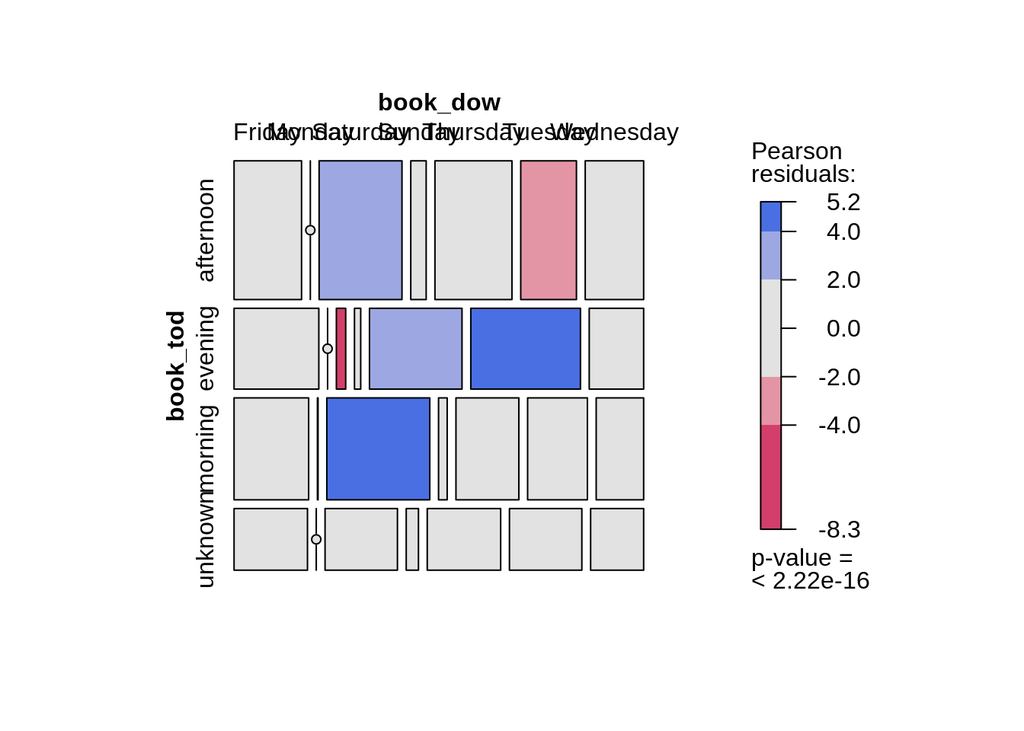

```r
require(vcd)
mosaic(tab, shade=T, legend=T)
```

The chi-squared shows the significant difference (p-value < 2.22e-16). Tuesday evenings and Saturday mornings get disproportionally more noshows. Saturday evenings and Tuesday afternoons get much less noshows.

Let’s remove the only one observation on Monday.

```r
full_df = filter(full_df, book_dow != "Monday")
```

## Hypothesis №2

The noshows are spread uniformly across those clients who sets apponintments with the master they’d been working before and those who chooses a new one.

```r
tab1 <- full_df %>% group_by(staff_match, noshow) %>% summarise(count = sum(as.numeric(noshow)))

tab1 = xtabs(count ~ staff_match + noshow, tab1)
chisq.test(tab1)
```

```
##
##  Pearson's Chi-squared test with Yates' continuity correction
##
## data:  tab1
## X-squared = 18.667, df = 1, p-value = 1.556e-05
```

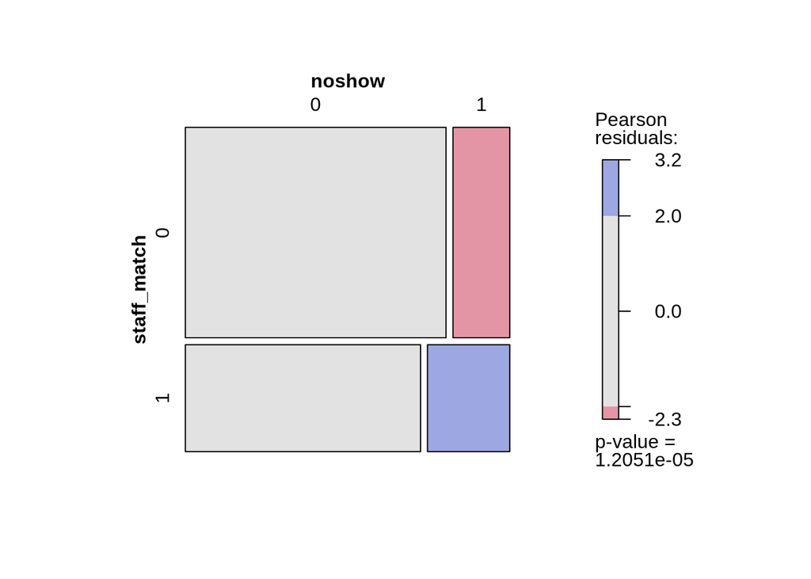

```r
mosaic(tab1, shade=T, legend=T)
```

## Trees

Let’s make test and train again. 80% goes to train, 20% to test.

```r
library(caret)
set.seed(483)

full_df <- na.omit(full_df)

trainIndex <- createDataPartition(full_df$noshow, p = .8,
                                  list = FALSE,
                                  times = 1)
noshowTrain <- full_df[ trainIndex,]
noshowTest  <- full_df[-trainIndex,]
```

[figure not shown]

```r
cv7 <- trainControl(method="cv", number = 7)
set.seed(483)
tree_model <- caret::train(noshow~., method = 'ctree', data = noshowTrain, trControl=cv7)
plot(tree_model$finalModel, type="simple") # use link below if the image is too messy
```

```r
predictions.on.train <- predict(tree_model, noshowTrain)
confusionMatrix(predictions.on.train, noshowTrain$noshow, positive = "1", mode = "prec_recall")
```

```
## Confusion Matrix and Statistics
##
##           Reference
## Prediction    0    1
##          0 1339   66
##          1   43  114
##
##                Accuracy : 0.9302
##                  95% CI : (0.9164, 0.9424)
##     No Information Rate : 0.8848
##     P-Value [Acc > NIR] : 1.241e-09
##
##                   Kappa : 0.6377
##  Mcnemar's Test P-Value : 0.0351
##
##               Precision : 0.72611
##                  Recall : 0.63333
##                      F1 : 0.67656
##              Prevalence : 0.11524
##          Detection Rate : 0.07298
##    Detection Prevalence : 0.10051
##       Balanced Accuracy : 0.80111
##
##        'Positive' Class : 1
##
```

The precision is 0.726 on the train sample, whoever on the test sample it is only 0.54.

```r
predictions.on.test <- predict(tree_model, noshowTest)
confusionMatrix(predictions.on.test, noshowTest$noshow, positive = "1", mode = "prec_recall")
```

```
## Confusion Matrix and Statistics
##
##           Reference
## Prediction   0   1
##          0 322  17
##          1  23  27
##
##                Accuracy : 0.8972
##                  95% CI : (0.8626, 0.9255)
##     No Information Rate : 0.8869
##     P-Value [Acc > NIR] : 0.2926
##
##                   Kappa : 0.5163
##  Mcnemar's Test P-Value : 0.4292
##
##               Precision : 0.54000
##                  Recall : 0.61364
##                      F1 : 0.57447
##              Prevalence : 0.11311
##          Detection Rate : 0.06941
##    Detection Prevalence : 0.12853
##       Balanced Accuracy : 0.77348
##
##        'Positive' Class : 1
##
```

## Let’s try to deal with the imbalance

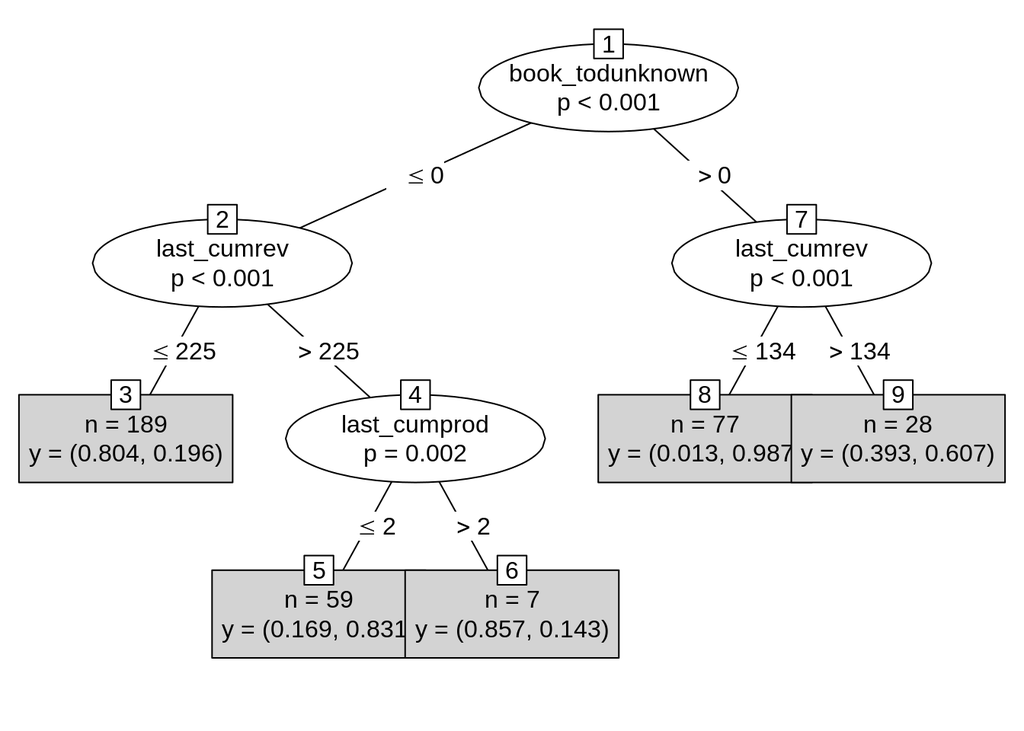

```r
set.seed(555)
cv5 <- trainControl(method="cv", number = 5)
cv5_down<-cv5
cv5_down$sampling<-"down"

tree_model_down <- caret::train(noshow~., method = 'ctree', data = noshowTrain, trControl=cv5_down)
plot(tree_model_down$finalModel, type="simple")
```

The `book_tod_unknown` remains to be the main split but the tree is less complicated.

```r
d.on.train <- predict(tree_model_down, noshowTrain)
confusionMatrix(d.on.train, noshowTrain$noshow, positive = "1", mode = "prec_recall")
```

```
## Confusion Matrix and Statistics
##
##           Reference
## Prediction    0    1
##          0 1217   38
##          1  165  142
##
##                Accuracy : 0.87
##                  95% CI : (0.8523, 0.8863)
##     No Information Rate : 0.8848
##     P-Value [Acc > NIR] : 0.967
##
##                   Kappa : 0.5123
##  Mcnemar's Test P-Value : <2e-16
##
##               Precision : 0.46254
##                  Recall : 0.78889
##                      F1 : 0.58316
##              Prevalence : 0.11524
##          Detection Rate : 0.09091
##    Detection Prevalence : 0.19654
##       Balanced Accuracy : 0.83475
##
##        'Positive' Class : 1
##
```

The precision significantly decreased both on the train and the test samples. However the model seems to be less overfitted.

```r
d.on.test <- predict(tree_model_down, noshowTest)
confusionMatrix(d.on.test, noshowTest$noshow, positive = "1", mode = "prec_recall")
```

```
## Confusion Matrix and Statistics
##
##           Reference
## Prediction   0   1
##          0 302  11
##          1  43  33
##
##                Accuracy : 0.8612
##                  95% CI : (0.8228, 0.894)
##     No Information Rate : 0.8869
##     P-Value [Acc > NIR] : 0.9503
##
##                   Kappa : 0.4747
##  Mcnemar's Test P-Value : 2.459e-05
##
##               Precision : 0.43421
##                  Recall : 0.75000
##                      F1 : 0.55000
##              Prevalence : 0.11311
##          Detection Rate : 0.08483
##    Detection Prevalence : 0.19537
##       Balanced Accuracy : 0.81268
##
##        'Positive' Class : 1
##
```

## Linear Regression models with and without regularization

```r
library(caret)
set.seed(483)

full_df <- na.omit(full_df)
full_df$book_tod <- as.factor(full_df$book_tod)

trainIndex <- createDataPartition(full_df$noshow, p = .8,
                                  list = FALSE,
                                  times = 1)
noshowTrain <- full_df[ trainIndex,]
noshowTest  <- full_df[-trainIndex,]

lmodel <- glm(noshow~., data = noshowTrain, family = binomial(link = "logit"))
summary(lmodel)
```

```
##
## Call:
## glm(formula = noshow ~ ., family = binomial(link = "logit"),
##     data = noshowTrain)
##
## Deviance Residuals:
##     Min       1Q   Median       3Q      Max
## -2.3829  -0.3713  -0.2913  -0.2258   2.9272
##
## Coefficients:
##                     Estimate Std. Error z value Pr(>|z|)
## (Intercept)        -1.657335   0.462595  -3.583  0.00034 ***
## book_todevening    -0.498130   0.303898  -1.639  0.10119
## book_todmorning    -0.706466   0.289798  -2.438  0.01478 *
## book_todunknown     2.503636   0.235856  10.615  < 2e-16 ***
## book_dowSaturday   -0.056233   0.315550  -0.178  0.85856
## book_dowSunday      1.030419   0.479076   2.151  0.03149 *
## book_dowThursday    0.200732   0.297789   0.674  0.50026
## book_dowTuesday    -0.029894   0.306818  -0.097  0.92238
## book_dowWednesday   0.102380   0.348915   0.293  0.76920
## book_categoryMISC   0.404321   0.531530   0.761  0.44685
## book_categorySTYLE -0.779308   0.368660  -2.114  0.03452 *
## book_staffHOUSE    -0.564716   1.109581  -0.509  0.61079
## book_staffJJ       -0.404232   0.258751  -1.562  0.11823
## book_staffJOANNE   -1.397159   0.483341  -2.891  0.00384 **
## book_staffKELLY    -0.457713   0.343522  -1.332  0.18272
## book_staffSINEAD   -0.067991   0.360929  -0.188  0.85058
## book_staffTANYA    -0.036695   0.856441  -0.043  0.96582
## last_day_services   0.209379   0.298623   0.701  0.48321
## last_receipt_tot    0.001198   0.002937   0.408  0.68335
## last_noshow         0.461612   0.392521   1.176  0.23959
## last_prod_flag     -0.314642   0.552347  -0.570  0.56892
## last_cumrev         0.008044   0.002017   3.988 6.68e-05 ***
## last_cumbook       -1.371348   0.498203  -2.753  0.00591 **
## last_cumstyle       0.843980   0.465219   1.814  0.06965 .
## last_cumcolor       0.559696   0.475431   1.177  0.23910
## last_cumprod       -0.183201   0.204726  -0.895  0.37086
## last_cumcancel      0.681809   0.235661   2.893  0.00381 **
## last_cumnoshow     -0.097805   0.181260  -0.540  0.58948
## recency            -0.015798   0.007098  -2.226  0.02604 *
## staff_match         0.447994   0.301934   1.484  0.13788
## category_match      0.133013   0.339645   0.392  0.69534
## ---
## Signif. codes:  0 '***' 0.001 '**' 0.01 '*' 0.05 '.' 0.1 ' ' 1
##
## (Dispersion parameter for binomial family taken to be 1)
##
##     Null deviance: 1116.29  on 1561  degrees of freedom
## Residual deviance:  805.73  on 1531  degrees of freedom
## AIC: 867.73
##
## Number of Fisher Scoring iterations: 6
```

```r
pred = predict(lmodel, newdata = noshowTest, type = "response")
```

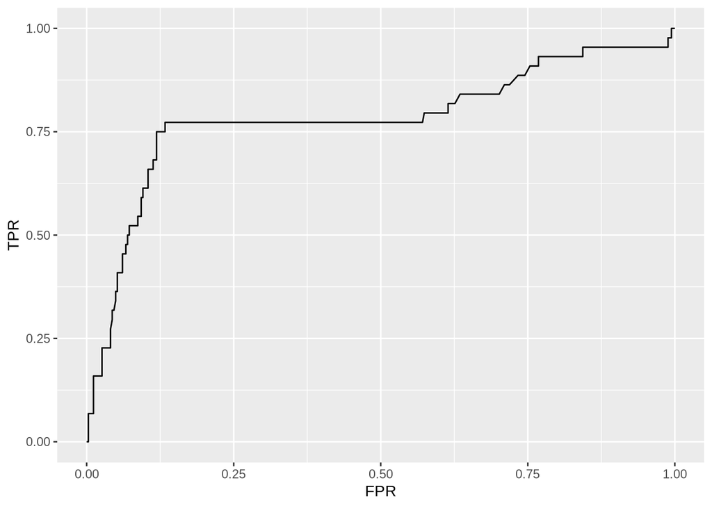

```r
library(pROC)
ROC = roc(response = noshowTest$noshow, predictor = pred)
aucSimple = pROC::auc(ROC)

ggplot() + geom_path(aes(y=ROC$sensitivities, x=1-ROC$specificities))+
  xlab("FPR") + ylab("TPR")
```

### Regularization

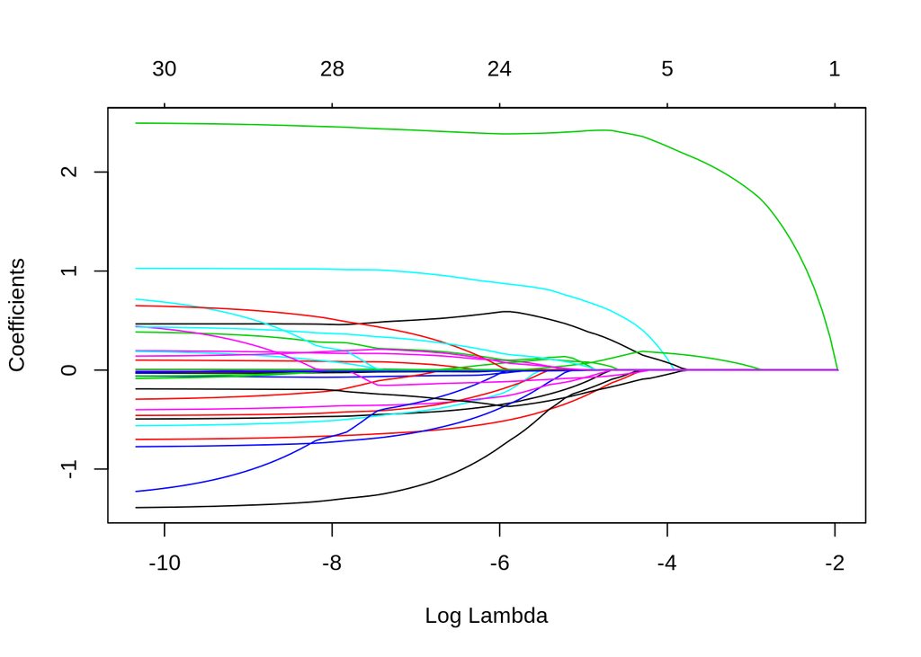

```r
library(glmnet)

X.train <- model.matrix(noshow~.-noshow, data=noshowTrain)
X.test <- model.matrix(noshow~.-noshow, data=noshowTest)

glmnet.fit<-glmnet(X.train, noshowTrain$noshow, family = "binomial")

glmnet.predictions <- predict(glmnet.fit, X.test, type = "response")

plot(glmnet.fit,xvar="lambda")
```

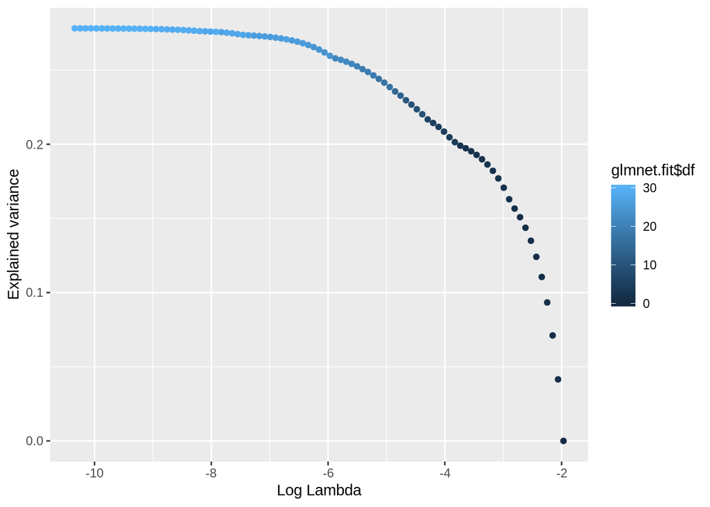

```r
ggplot()+
  geom_point(aes(x=log(glmnet.fit$lambda), y=glmnet.fit$dev.ratio, color = glmnet.fit$df)) +
  xlab("Log Lambda") +
  ylab("Explained variance")
```

```r
cv.glmnet.fit<-cv.glmnet(X.train, noshowTrain$noshow, family = "binomial")
best.lambda <- cv.glmnet.fit$lambda.min
best.lambda
```

```
## [1] 0.01499133
```

```r
glmnet.fit.best<-glmnet(X.train, noshowTrain$noshow, family = "binomial", lambda = best.lambda)
coef(glmnet.fit.best)
```

```
## 33 x 1 sparse Matrix of class "dgCMatrix"
##                             s0
## (Intercept)        -2.67682339
## (Intercept)         .
## book_todevening     .
## book_todmorning     .
## book_todunknown     2.32943851
## book_dowMonday      .
## book_dowSaturday    .
## book_dowSunday      0.32487145
## book_dowThursday    .
## book_dowTuesday     .
## book_dowWednesday   .
## book_categoryMISC   .
## book_categorySTYLE  .
## book_staffHOUSE     .
## book_staffJJ        .
## book_staffJOANNE    .
## book_staffKELLY     .
## book_staffSINEAD    .
## book_staffTANYA     .
## last_day_services   .
## last_receipt_tot    .
## last_noshow         0.12704723
## last_prod_flag      .
## last_cumrev         .
## last_cumbook        .
## last_cumstyle       .
## last_cumcolor       .
## last_cumprod       -0.08228297
## last_cumcancel      .
## last_cumnoshow      0.18291443
## recency             .
## staff_match         .
## category_match      .
```

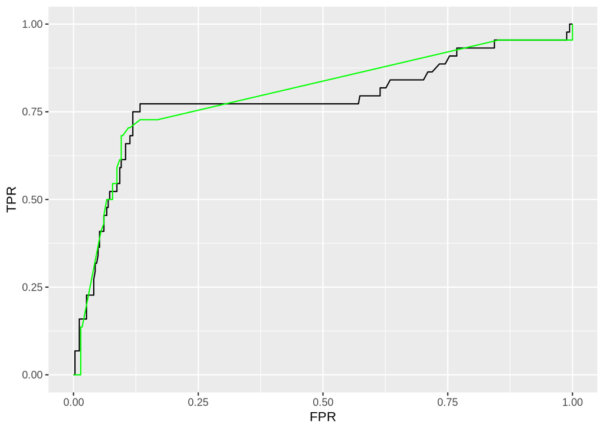

```r
glmnet.predictions.best <- predict(glmnet.fit.best, X.test, type = "response")

ROC_lasso = roc(response = noshowTest$noshow, predictor = glmnet.predictions.best)
aucLasso = pROC::auc(ROC_lasso)

ggplot() + geom_path(aes(y=ROC$sensitivities, x=1-ROC$specificities), color = "black")+
  geom_path(aes(y=ROC_lasso$sensitivities, x=1-ROC_lasso$specificities), color = "green") +
  xlab("FPR") + ylab("TPR")
```

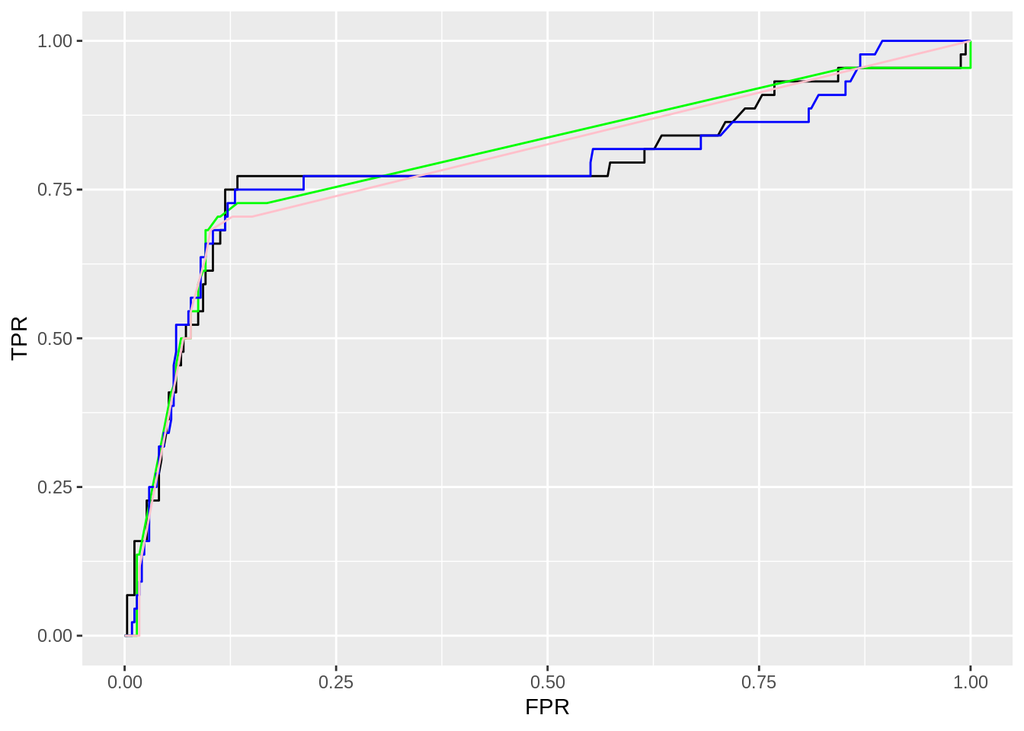

| Метод | AUC-ROC |
| --- | --- |
| LM | 0.7817194 |
| LASSO | 0.7999012 |
| Ridge | 0.7804018 |
| Elastic 0.5 | 0.7926877 |

```r
ridge <-cv.glmnet(X.train, noshowTrain$noshow, family = "binomial", alpha = 0)
elastic<-cv.glmnet(X.train, noshowTrain$noshow, family = "binomial", alpha = 0.5)

glmnet.predictions.ridge <- predict(ridge, X.test, type = "response")
glmnet.predictions.elastic <- predict(elastic, X.test, type = "response")

ROC_ridge = roc(response = noshowTest$noshow, predictor = glmnet.predictions.ridge)
aucRidge = pROC::auc(ROC_ridge)
ROC_elastic = roc(response = noshowTest$noshow, predictor = glmnet.predictions.elastic)
aucElastic = pROC::auc(ROC_elastic)

ggplot() + geom_path(aes(y=ROC$sensitivities, x=1-ROC$specificities), color = "black")+
  geom_path(aes(y=ROC_lasso$sensitivities, x=1-ROC_lasso$specificities), color = "green") +
  geom_path(aes(y=ROC_ridge$sensitivities, x=1-ROC_ridge$specificities), color = "blue") +
  geom_path(aes(y=ROC_elastic$sensitivities, x=1-ROC_elastic$specificities), color = "pink") +
  xlab("FPR") + ylab("TPR")
```

**Conclusion:** the best linear model (LASSO) achieves almost 0.8 AUC-ROC